# Monumentome supplementary figures

```r
  # Ring 1: prevalence in each focal group (percent of samples with the species detected).
  ring_prev <- species_summary %>%
    filter(taxon %in% tree_lineage$taxon) %>%
    transmute(taxon, focal_group = factor(focal_group, levels = FOCAL_GROUP_LEVELS, labels = unname(FOCAL_LEGEND_LABELS[FOCAL_GROUP_LEVELS])), prevalence, prevalence_shown = if_else(prevalence > 0, prevalence, NA_real_))
  # Ring 2: every Microbe Directory trait listed for at least one of the 224 matched species.
  tree_trait_group <- TMD_TRAITS %>%
    distinct(trait, trait_group) %>%
    filter(trait %in% tree_trait_levels) %>%
    mutate(trait_group = recode(trait_group, "Surface persistence" = "Surface"))
  ring_trait <- tidyr::crossing(
    tree_lineage %>% transmute(taxon, species_match_key = clean_tmd_species(taxon)),
    trait = tree_trait_levels
  ) %>%
    left_join(tmd_species_traits %>% distinct(species_match_key, trait) %>% mutate(present = TRUE), by = c("species_match_key", "trait")) %>%
    left_join(tree_trait_group, by = "trait") %>%
    mutate(
      trait = factor(trait, levels = tree_trait_levels),
      trait_fill = factor(if_else(!is.na(present), as.character(trait), NA_character_), levels = tree_trait_levels)
    )
  # One colour per trait, in a colour family per trait group (orange: extremophile, green: surface, blue: metabolism).
  TREE_TRAIT_COLORS <- unlist(lapply(c("Extremophile", "Surface", "Metabolism"), function(g) {
    tr <- tree_trait_group$trait[tree_trait_group$trait_group == g]
    tr <- tr[order(match(tr, tree_trait_levels))]
    ends <- switch(g, Extremophile = c("#7F2704", "#FDD49E"), Surface = c("#00441B", "#A1D99B"), Metabolism = c("#08306B", "#9ECAE1"))
    setNames(grDevices::colorRampPalette(ends)(length(tr)), tr)
  }))

  # Ring geometry in inches (print size): tree radius, and one column per focal group or trait.
  # 224 species names set the geometry: the names are read outward from the outer ring, so
  # the rings are kept narrow and the tree small to leave room for them inside 180 mm.
  K <- FIG_BASE_SIZE / 7
  TREE_R_IN <- 1.2
  COL_IN <- 0.045
  GAP_IN <- 0.03
  TREE_LABEL_PT <- 4.5 * K
  TREE_TIP_PT <- 4.5 * K
  TREE_OUTER_R_IN <- 3.05
  n_prev_cols <- length(FOCAL_GROUP_LEVELS)
  n_trait_cols <- length(tree_trait_levels)
  # ggtreeExtra evaluates the axis settings late, outside this local scope, so they are passed as values.
  tree_axis_params <- list(axis = "x", text.size = pt_to_mm(TREE_LABEL_PT), text.angle = -90, hjust = 0, vjust = 0.5, line.size = 0, line.alpha = 0, line.color = NA)
  tree_base <- ggtree::ggtree(tax_tree, layout = "fan", open.angle = 40, branch.length = "none",
                              aes(color = phylum_group), size = gs(0.3), alpha = 0.6)
  tree_depth <- max(tree_base$data$x)
  p_rings <- tree_base +
    scale_color_manual(values = PHYLUM_COLORS, name = "Phylum\n(branch colour)", breaks = names(PHYLUM_COLORS), guide = guide_legend(order = 1, nrow = 4, override.aes = list(linewidth = gs(2)))) +
    ggnewscale::new_scale_fill() +
    rlang::inject(ggtreeExtra::geom_fruit(
      data = ring_prev, geom = geom_point, shape = 22, size = 1.15 * K, stroke = 0, colour = "transparent",
      mapping = aes(y = taxon, x = focal_group, fill = prevalence_shown),
      offset = GAP_IN / TREE_R_IN, pwidth = n_prev_cols * COL_IN / TREE_R_IN,
      axis.params = !!tree_axis_params
    )) +
    scale_fill_gradientn(colours = c("#FFFFCC", "#A1DAB4", "#41B6C4", "#225EA8", "#081D58"), limits = c(0, 100), na.value = "transparent", transform = "sqrt", breaks = c(0, 10, 25, 50, 100), name = "Prevalence in\ngroup (%)",
                         guide = guide_colourbar(order = 2, direction = "horizontal", barwidth = unit(by_mode(3.2, 1.6), "cm"), barheight = unit(by_mode(0.55, 0.25), "cm"))) +
    ggnewscale::new_scale_fill() +
    rlang::inject(ggtreeExtra::geom_fruit(
      data = ring_trait, geom = geom_point, shape = 22, size = 1.35 * K, stroke = 0, colour = "transparent",
      mapping = aes(y = taxon, x = trait, fill = trait_fill),
      offset = GAP_IN / TREE_R_IN, pwidth = n_trait_cols * COL_IN / TREE_R_IN,
      axis.params = !!tree_axis_params
    )) +
    scale_fill_manual(values = TREE_TRAIT_COLORS, na.value = "transparent", name = "Microbe Directory trait", breaks = tree_trait_levels, drop = FALSE,
                      guide = guide_legend(order = 3, nrow = 6, override.aes = list(shape = 22, size = gs(5), colour = "transparent"))) +
    ggplot2::theme(plot.margin = margin(0, 0, 0, 0))
  # The names start just outside the outer ring. The ring edge is read from the built plot,
  # because ggtreeExtra places the rings in its own units.
  ring_built <- ggplot2::ggplot_build(p_rings)
  # The squares are points, so the edge is the outermost point centre plus half a column.
  ring_edge <- max(vapply(ring_built$data, function(d) if (all(c("x", "shape", "size") %in% names(d))) max(d$x, na.rm = TRUE) else NA_real_, numeric(1)), na.rm = TRUE) +
    tree_depth * COL_IN / TREE_R_IN / 2
  tip_edge <- max(tree_base$data$x)
  label_offset <- ring_edge - tip_edge + tree_depth * GAP_IN / TREE_R_IN
  # Species names, set 4.5 pt (the only text below 5 pt) so 224 names fit one circle.
  p_tree <- p_rings +
    ggtree::geom_tiplab(aes(label = str_replace_all(label, "_", " "), color = NULL), align = TRUE, linesize = 0, offset = label_offset,
                        size = pt_to_mm(TREE_TIP_PT), family = FIG_FONT, fontface = "italic", color = "black") +
    ggtree::xlim_tree(tree_depth * TREE_OUTER_R_IN / TREE_R_IN) +
    theme(
      legend.position = "bottom", legend.box = "horizontal", legend.box.just = "top", legend.title.position = "top",
      legend.spacing.y = unit(by_mode(0.5, 0.2), "cm"),
      legend.title = element_text(face = "bold", size = FIG_LEGEND_TITLE_SIZE, family = FIG_FONT),
      legend.text = element_text(size = FIG_LEGEND_TEXT_SIZE, family = FIG_FONT),
      legend.key.size = unit(by_mode(0.55, 0.25), "cm"),
      plot.margin = margin(0.12 * K, 0.05 * K, 0, 0.05 * K, "in")
    )
```

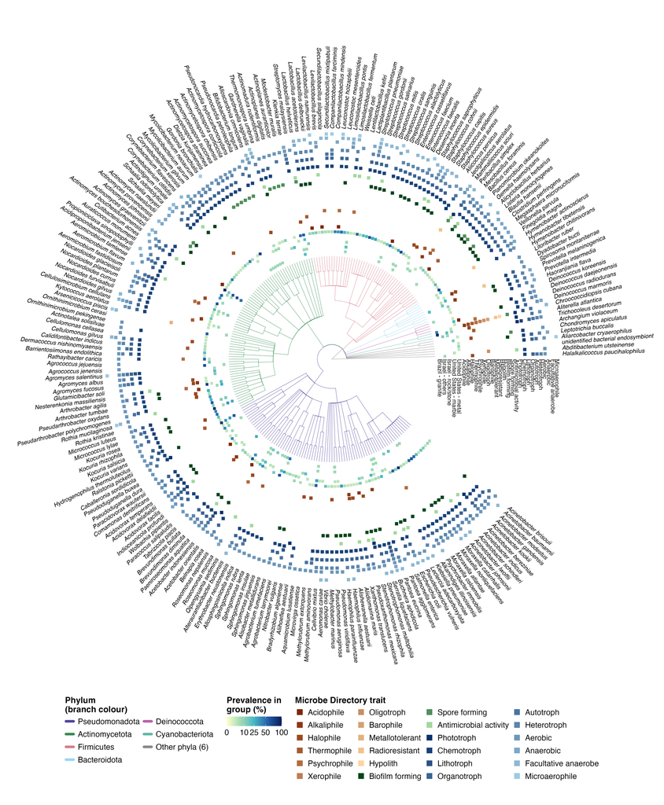

```r
  TREE_PAGE_HEIGHT <- 8.6

  tree_table <- tree_lineage %>%
    select(taxon, kingdom, phylum, class, order, family, genus) %>%
    left_join(ring_prev %>% select(taxon, focal_group, prevalence) %>% mutate(focal_group = as.character(focal_group)) %>% tidyr::pivot_wider(names_from = focal_group, values_from = prevalence, names_prefix = "prevalence_"), by = "taxon") %>%
    left_join(
      ring_trait %>% filter(!is.na(present)) %>% group_by(taxon) %>% summarise(microbe_directory_traits = paste(trait, collapse = "; "), .groups = "drop"),
      by = "taxon"
    ) %>%
    arrange(kingdom, phylum, class, order, family, genus, taxon)
  readr::write_tsv(tree_table, file.path(OUTPUT_DIR, "FigureS6_tree_species.tsv"))

  if (is_print()) {
    tree_files <- save_page(p_tree, OUTPUT_DIR, "FigureS6_microbe_directory_tree", height = TREE_PAGE_HEIGHT)
  } else {
    tree_files <- save_panel(p_tree, FIGS6_DIR, "FigureS6_microbe_directory_tree", width = PRINT_WIDTH_IN * K, height = TREE_PAGE_HEIGHT * K)
  }
  list(files = tree_files, phylum_min = PHYLUM_MIN_SPECIES, n_species = nrow(tree_lineage), n_phyla = n_distinct(tree_lineage$phylum), n_traits = length(tree_trait_levels), n_big_phyla = length(big_phyla), n_other = sum(!phylum_counts$phylum %in% big_phyla))
})
knitr::include_graphics(tree_result$files)
```

The tree is a taxonomy dendrogram, not a phylogeny. Its branches follow the MetaPhlAn lineage of each species (kingdom, phylum, class, order, family, genus, species), every branch has the same length, and the tips are aligned on the outer circle. It shows which lineages the matched species belong to. It does not show evolutionary distance. Branch color is the phylum. Phyla with fewer than 3 matched species are pooled into one grey group (6 phyla).

Moving outward from the tree there are two rings of small squares. The inner ring has one column per focal group, in the order Brazil granite, Israel others, Israel rock/stone, United States marble, and United States metal. A square is drawn when the species was detected in that group, and its color is the prevalence, the percent of the group’s samples in which it was detected (square-root scale, so low values show). The outer ring has one column per Microbe Directory trait listed for at least one of these species (24 traits). Pigment producer and UV resistance are not drawn, because no matched species is listed with them. A square means the directory lists that trait for the species. Each trait has its own color, in an orange family for extremophile traits, a green family for surface persistence, and a blue family for metabolism. The branches are drawn thin and pale so the squares carry the figure. Every species is named at its tip, in italics, outside the outer ring. Those names are set at 4.5 pt, the only text in the supplement below the 5 pt minimum, because 224 names will not fit around a 180 mm circle at a larger size. The lineage, prevalence in each group, and traits of every species are also listed in `paper_output/FigureS6_tree_species.tsv`, in tree order.

The tree is `paper_output/FigureS6_microbe_directory_tree.pdf` and `paper_output/FigureS6_microbe_directory_tree.png`. The panel is also in `paper_output/FigureS6/`. The table behind it is `paper_output/FigureS6_tree_species.tsv`. The matched Microbe Directory rows are in `paper_output/FigureS6_microbe_directory_annotations.tsv`.

# Supplementary Figure 7. Insertion sequence (IS) elements in the focal groups

```r
FIGS7_DIR <- file.path(OUTPUT_DIR, "FigureS7")
IS_FILE <- file.path(ROOT, "input", "ISelements_LengthComplFamClusterInfo_UPDATED.xlsx")
# Every inch value below is written for the 180 mm print page. In check mode the same layout
# is drawn at the larger check text size, so all lengths are scaled by the same ratio.
K <- FIG_BASE_SIZE / 7
focal_sample_key_is <- focal_sample_key
is_result <- local({
  # ---- IS table and the IS-cluster matrix (as in MonumentIS.R) -------------------------------
  is_input_table <- readxl::read_excel(IS_FILE)
  ISdat <- is_input_table %>% filter(sample %in% focal_sample_key_is$sample_name_clean)

  cluster_matrix <- ISdat %>%
    select(sample, cluster) %>%
    count(sample, cluster) %>%
    pivot_wider(names_from = cluster, values_from = n, values_fill = 0)
  cluster_matrix <- as.data.frame(cluster_matrix)
  rownames(cluster_matrix) <- cluster_matrix$sample
  cluster_matrix$sample <- NULL
  cluster_matrix <- as.matrix(cluster_matrix)

  # Keep every focal sample with at least one IS cluster (104 of 112).
  keep_samples <- rownames(cluster_matrix)[rowSums(cluster_matrix > 0) >= 1]
  cluster_matrix <- cluster_matrix[keep_samples, colSums(cluster_matrix[keep_samples, , drop = FALSE]) > 0, drop = FALSE]
  ISdat <- ISdat %>% filter(sample %in% keep_samples)

  meta2 <- focal_sample_key_is %>% filter(sample_name_clean %in% rownames(cluster_matrix))
  meta2 <- meta2[match(rownames(cluster_matrix), meta2$sample_name_clean), ]
  stopifnot(identical(rownames(cluster_matrix), meta2$sample_name_clean))

  group_scale_color <- scale_color_manual(values = FOCAL_GROUP_COLORS, labels = FOCAL_LEGEND_LABELS, drop = FALSE, name = "Focal group")
  group_scale_fill <- scale_fill_manual(values = FOCAL_GROUP_COLORS, labels = FOCAL_LEGEND_LABELS, drop = FALSE, name = "Focal group")

  # ---- A. Number of IS per sample ------------------------------------------------------------
  cou <- as.data.frame(table(ISdat$sample), stringsAsFactors = FALSE)
  cou_meta <- merge(meta2, cou, by.x = "sample_name_clean", by.y = "Var1")
  cou_meta$focal_group <- factor(cou_meta$focal_group, levels = FOCAL_GROUP_LEVELS)
  is_count_kw <- kruskal.test(Freq ~ focal_group, data = cou_meta)

  p_a <- ggplot(cou_meta, aes(focal_group, Freq, color = focal_group, fill = focal_group)) +
    geom_boxplot(outlier.shape = NA, alpha = 0.35) +
    geom_jitter(width = 0.15, size = gs(2.2), alpha = 0.85, show.legend = FALSE) +
    group_scale_color + group_scale_fill +
    scale_x_discrete(labels = focal_axis_labels()) +
    labs(
      tag = "A",
      title = "IS elements per sample",
      subtitle = sprintf("Kruskal-Wallis p = %.3g", is_count_kw$p.value),
      x = NULL,
      y = "Number of IS elements"
    ) +
    paper_theme_upright() +
    theme(
      legend.position = "none",
      axis.text.x = element_text(size = by_mode(FIG_BASE_SIZE, 5.5))
    )

  # ---- C. Cluster richness -------------------------------------------------------------------
  alpha_data <- meta2 %>%
    mutate(
      richness = specnumber(cluster_matrix),
      shannon = diversity(cluster_matrix, index = "shannon")
    )
  richness_kw <- kruskal.test(richness ~ focal_group, data = alpha_data)
  p_c <- ggplot(alpha_data, aes(focal_group, richness, color = focal_group, fill = focal_group)) +
    geom_boxplot(outlier.shape = NA, alpha = 0.35) +
    geom_jitter(width = 0.15, size = gs(2.2), alpha = 0.85, show.legend = FALSE) +
    group_scale_color + group_scale_fill +
    scale_x_discrete(labels = focal_axis_labels()) +
    labs(
      tag = "C",
      title = "IS cluster richness",
      subtitle = sprintf("Kruskal-Wallis p = %.3g", richness_kw$p.value),
      x = NULL,
      y = "Number of IS clusters"
    ) +
    paper_theme_upright() +
    theme(
      legend.position = "none",
      axis.text.x = element_text(size = by_mode(FIG_BASE_SIZE, 5.5))
    )

  # ---- B. UpSet plot: IS clusters shared between focal groups --------------------------------
  pa_matrix <- cluster_matrix > 0
  group_matrix <- sapply(FOCAL_GROUP_LEVELS, function(g) {
    colSums(pa_matrix[meta2$focal_group == g, , drop = FALSE]) > 0
  })
  colnames(group_matrix) <- unname(FOCAL_LEGEND_LABELS[FOCAL_GROUP_LEVELS])
  group_matrix <- as.data.frame(group_matrix)

  # ComplexUpset (used in MonumentIS.R) does not run with the installed ggplot2 4.x, so the
  # plot is drawn with ggplot directly, in inch coordinates like Figure 6B: one bar per exact
  # combination of groups, a dot matrix below it, and the number of clusters in each group on
  # the left. The intersection bars use a log10 axis, because the counts run from 1 to tens of
  # thousands and the linear scale would hide every shared set; each bar is labelled with its
  # exact count.
  up_sets <- unname(FOCAL_LEGEND_LABELS[FOCAL_GROUP_LEVELS])
  up_pattern <- apply(as.matrix(group_matrix[, up_sets]) + 0L, 1, paste, collapse = "")
  up_combos <- tibble(pattern = up_pattern) %>%
    count(pattern, name = "n_clusters") %>%
    mutate(degree = str_count(pattern, "1")) %>%
    filter(degree > 0) %>%
    arrange(desc(n_clusters), desc(degree), pattern) %>%
    mutate(combo = row_number())
  n_cols <- nrow(up_combos)
  n_rows <- length(up_sets)
  up_membership <- tidyr::crossing(combo = up_combos$combo, set_index = seq_len(n_rows)) %>%
    left_join(up_combos, by = "combo") %>%
    mutate(member = substr(pattern, set_index, set_index) == "1")
  up_links <- up_membership %>%
    filter(member) %>%
    group_by(combo) %>%
    summarise(y_min = min(set_index), y_max = max(set_index), .groups = "drop") %>%
    filter(y_max > y_min)
  up_set_sizes <- tibble(set_index = seq_len(n_rows), n_clusters = colSums(group_matrix[, up_sets]))

  # Layout in inches
  UP_ROW_H <- 0.2 * K
  UP_SIZE_W <- 0.95 * K
  UP_NAMES_W <- 1.25 * K
  UP_TOP_H <- 1.35 * K
  up_sizes_x0 <- 0.55 * K + UP_SIZE_W                      # right end of the set-size bars
  up_matrix_x0 <- up_sizes_x0 + 0.12 * K + UP_NAMES_W + 0.08 * K
  UP_COL_W <- min(0.32 * K, (PRINT_WIDTH_IN * K - up_matrix_x0 - 0.1 * K) / n_cols)
  up_matrix_x1 <- up_matrix_x0 + n_cols * UP_COL_W
  up_matrix_y0 <- 0.75 * K
  up_matrix_y1 <- up_matrix_y0 + n_rows * UP_ROW_H
  up_top_base <- up_matrix_y1 + 0.12 * K
  up_width <- up_matrix_x1 + 0.1 * K
  up_height <- up_top_base + UP_TOP_H + 0.5 * K
```

```r
  col_x <- function(i) up_matrix_x0 + (i - 0.5) * UP_COL_W
  row_y <- function(j) up_matrix_y0 + (j - 0.5) * UP_ROW_H
  # first group on top
  row_of <- function(set_index) n_rows + 1 - set_index
  log_floor <- 0.5                                       # the bar axis starts at 0.5 clusters
  top_h <- function(n) UP_TOP_H * log10(n / log_floor) / log10(max(up_combos$n_clusters) / log_floor)
  top_ticks <- 10^(0:floor(log10(max(up_combos$n_clusters))))
  size_scale <- UP_SIZE_W / max(up_set_sizes$n_clusters)
  size_ticks <- c(0, 0.5, 1) * 10^floor(log10(max(up_set_sizes$n_clusters)))
  size_ticks <- size_ticks[size_ticks <= max(up_set_sizes$n_clusters)]
  up_text <- pt_to_mm(FIG_BASE_SIZE)
  up_small <- pt_to_mm(FIG_LEGEND_TEXT_SIZE)
  top_axis_x <- up_matrix_x0 - 0.06 * K
  size_axis_y <- up_matrix_y0 - 0.07 * K
  fmt <- function(v) format(v, big.mark = ",", scientific = FALSE, trim = TRUE)

  p_b <- ggplot() +
    geom_rect(
      data = tibble(j = seq(1, n_rows, by = 2)),
      aes(xmin = up_matrix_x0 - 0.03 * K, xmax = up_matrix_x1, ymin = row_y(j) - UP_ROW_H / 2, ymax = row_y(j) + UP_ROW_H / 2),
      fill = "grey94"
    ) +
    # dot matrix: grey = not in the combination, group color = in it
    geom_point(data = up_membership, aes(col_x(combo), row_y(row_of(set_index))), colour = "grey80", size = gs(4)) +
    geom_segment(data = up_links, aes(x = col_x(combo), xend = col_x(combo), y = row_y(row_of(y_max)), yend = row_y(row_of(y_min))), linewidth = gs(1.4), colour = "grey15") +
    geom_point(
      data = filter(up_membership, member),
      aes(col_x(combo), row_y(row_of(set_index))),
      colour = unname(FOCAL_GROUP_COLORS[FOCAL_GROUP_LEVELS])[filter(up_membership, member)$set_index],
      size = gs(5)
    ) +
    geom_text(data = tibble(j = seq_len(n_rows), label = rev(up_sets)), aes(x = up_matrix_x0 - 0.1 * K, y = row_y(j), label = label), hjust = 1, size = up_text) +
    # intersection bars (log10 axis)
    geom_rect(
      data = up_combos,
      aes(xmin = col_x(combo) - 0.7 * UP_COL_W / 2, xmax = col_x(combo) + 0.7 * UP_COL_W / 2, ymin = up_top_base, ymax = up_top_base + top_h(n_clusters)),
      fill = "grey25"
    ) +
    geom_text(
      data = up_combos,
      aes(x = col_x(combo), y = up_top_base + top_h(n_clusters) + 0.03 * K, label = fmt(n_clusters)),
      angle = 90, hjust = 0, vjust = 0.5, size = up_small
    ) +
    annotate("segment", x = top_axis_x, xend = top_axis_x, y = up_top_base, yend = up_top_base + UP_TOP_H, linewidth = gs(0.5)) +
    annotate("segment", x = top_axis_x - 0.05 * K, xend = top_axis_x, y = up_top_base + top_h(top_ticks), yend = up_top_base + top_h(top_ticks), linewidth = gs(0.5)) +
    annotate("text", x = top_axis_x - 0.08 * K, y = up_top_base + top_h(top_ticks), label = fmt(top_ticks), hjust = 1, size = up_small) +
    annotate("text", x = top_axis_x - (0.08 + 0.33 + 0.09) * K, y = up_top_base + UP_TOP_H / 2, label = "Shared IS clusters\n(log scale)",
             angle = 90, vjust = 0, hjust = 0.5, size = pt_to_mm(FIG_AXIS_TITLE_SIZE), lineheight = 0.95) +
    # set-size bars (linear axis)
    geom_rect(
      data = up_set_sizes,
      aes(xmin = up_sizes_x0 - n_clusters * size_scale, xmax = up_sizes_x0, ymin = row_y(row_of(set_index)) - UP_ROW_H * 0.3, ymax = row_y(row_of(set_index)) + UP_ROW_H * 0.3),
      fill = unname(FOCAL_GROUP_COLORS[FOCAL_GROUP_LEVELS])
    ) +
    geom_text(
      data = up_set_sizes,
      aes(x = up_sizes_x0 - n_clusters * size_scale - 0.03 * K, y = row_y(row_of(set_index)), label = fmt(n_clusters)),
      hjust = 1, size = up_small
    ) +
    annotate("segment", x = up_sizes_x0 - max(size_ticks) * size_scale, xend = up_sizes_x0, y = size_axis_y, yend = size_axis_y, linewidth = gs(0.5)) +
    annotate("segment", x = up_sizes_x0 - size_ticks * size_scale, xend = up_sizes_x0 - size_ticks * size_scale, y = size_axis_y, yend = size_axis_y - 0.05 * K, linewidth = gs(0.5)) +
    annotate("text", x = up_sizes_x0 - size_ticks * size_scale, y = size_axis_y - 0.08 * K, label = fmt(size_ticks), vjust = 1, size = up_small) +
    annotate("text", x = up_sizes_x0 - UP_SIZE_W / 2, y = size_axis_y - (0.08 + 0.12 + 0.07) * K, label = "IS clusters per group", vjust = 1, hjust = 0.5, size = pt_to_mm(FIG_AXIS_TITLE_SIZE)) +
    annotate("text", x = 0.02 * K, y = up_height - 0.04 * K, label = "B", hjust = 0, vjust = 1, fontface = "bold", size = pt_to_mm(FIG_TAG_SIZE)) +
    annotate("text", x = 0.3 * K, y = up_height - 0.05 * K, label = "IS clusters shared between focal groups", hjust = 0, vjust = 1, fontface = "bold", size = pt_to_mm(FIG_TITLE_SIZE)) +
    coord_fixed(xlim = c(0, up_width), ylim = c(0, up_height), expand = FALSE, clip = "off") +
    theme_void(base_family = FIG_FONT) +
    theme(plot.margin = margin(0, 0, 0, 0), plot.background = element_rect(fill = "white", colour = NA))

  # ---- D. Alpha diversity: Shannon (settings of Figure 2D) -----------------------------------
  shannon_kw <- kruskal.test(shannon ~ focal_group, data = alpha_data)

  p_d <- ggplot(alpha_data, aes(focal_group, shannon, color = focal_group, fill = focal_group)) +
    geom_boxplot(outlier.shape = NA, alpha = 0.35) +
    geom_jitter(width = 0.15, size = gs(2.2), alpha = 0.85, show.legend = FALSE) +
    group_scale_color + group_scale_fill +
    scale_x_discrete(labels = focal_axis_labels()) +
    labs(
      tag = "D",
      title = "Shannon diversity of IS clusters",
      subtitle = sprintf("Kruskal-Wallis p = %.3g", shannon_kw$p.value),
      x = NULL,
      y = "Shannon diversity"
    ) +
    paper_theme_upright() +
    theme(
      legend.position = "none",
      axis.text.x = element_text(size = by_mode(FIG_BASE_SIZE, 5.5))
    )

  # ---- E. Beta diversity: Jaccard NMDS + PERMANOVA (settings of Figure 2E) -------------------
  is_beta <- jaccard_beta(
    cluster_matrix,
    meta2$focal_group,
    nperm = N_PERMUTATIONS,
    seed = RANDOM_SEED
  )
  permanova <- is_beta$permanova
  nmds_data <- meta2 %>%
    inner_join(tibble::rownames_to_column(is_beta$scores, "sample_name_clean"), by = "sample_name_clean")
```

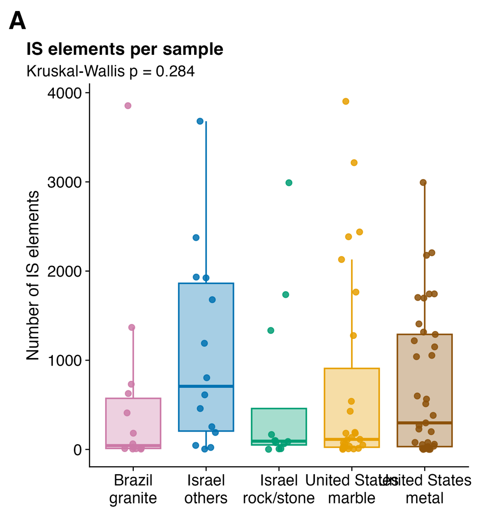

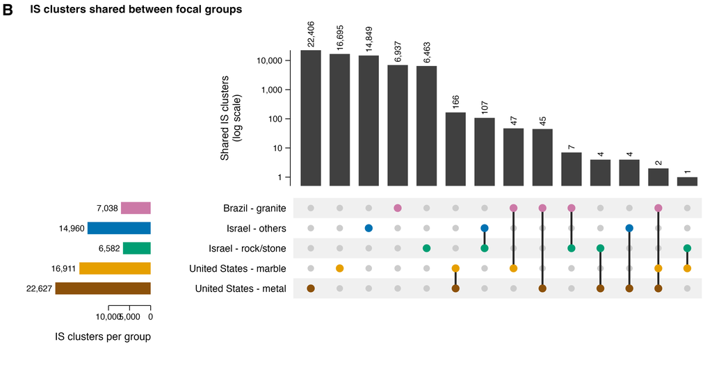

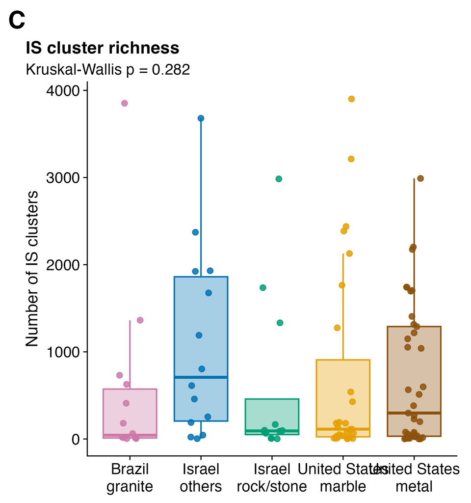

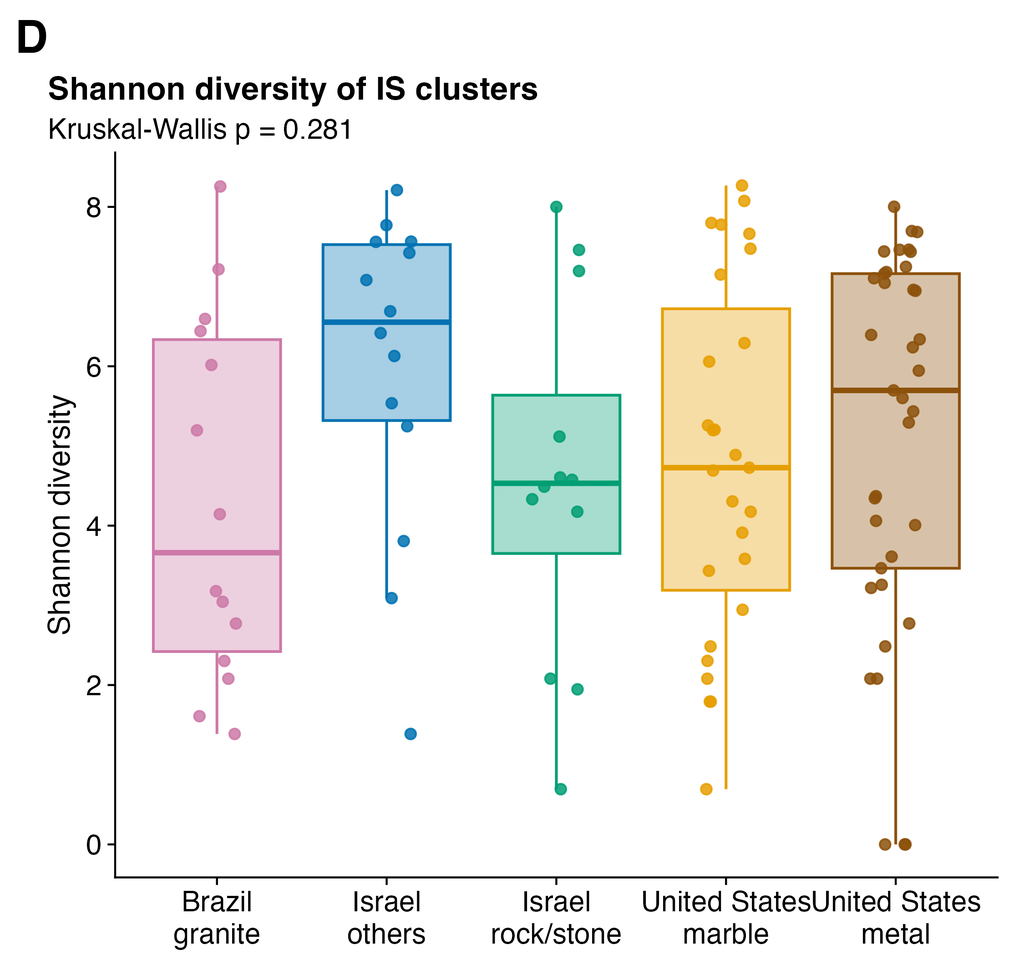

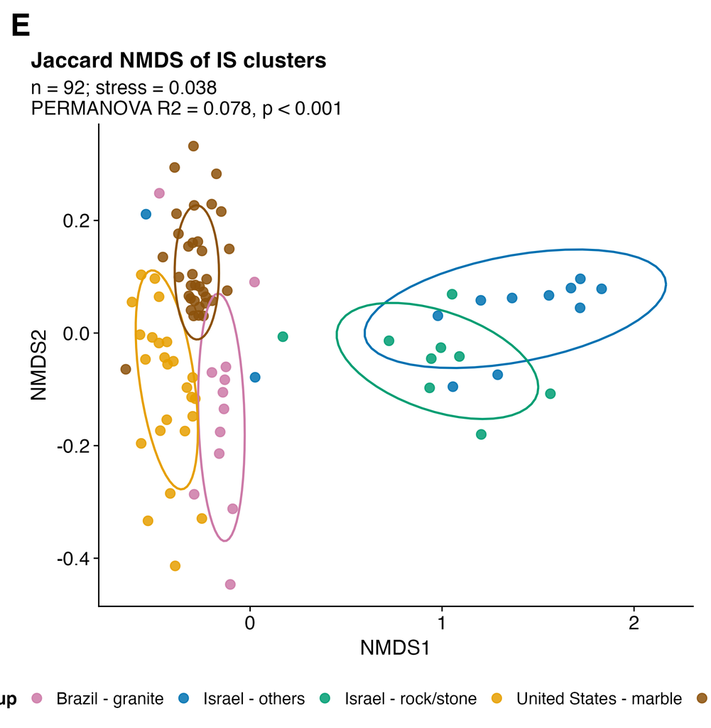

```r
  p_e <- ggplot(nmds_data, aes(NMDS1, NMDS2, color = focal_group)) +
    geom_point(size = gs(3), alpha = 0.85) +
    stat_ellipse(aes(group = focal_group), level = ELLIPSE_LEVEL, linewidth = gs(0.8), show.legend = FALSE) +
    group_scale_color +
    labs(
      tag = "E",
      title = "Jaccard NMDS of IS clusters",
      subtitle = sprintf(
        "n = %d; stress = %.3f\nPERMANOVA R2 = %.3f, %s",
        is_beta$n_samples, is_beta$stress, permanova$R2[1], perm_p_text(permanova$`Pr(>F)`[1])
      ),
      x = "NMDS1",
      y = "NMDS2"
    ) +
    paper_theme_continuous() +
    theme(legend.position = "none")


  group_legend_src <- ggplot(tibble(focal_group = factor(FOCAL_GROUP_LEVELS, levels = FOCAL_GROUP_LEVELS), x = 1, y = 1), aes(x, y, color = focal_group)) +
    geom_point(size = gs(6)) +
    group_scale_color +
    guides(color = guide_legend(nrow = 1, override.aes = list(size = gs(5.5)))) +
    theme_void(base_family = FIG_FONT) +
    theme(legend.position = "bottom", legend.title = element_text(face = "bold", size = FIG_LEGEND_TITLE_SIZE),
          legend.text = element_text(size = FIG_LEGEND_TEXT_SIZE), legend.key.size = unit(0.3 * K, "cm"))
  focal_legend <- blk(cowplot::get_legend(group_legend_src))

  is_page_heights <- c(2.55, up_height / K, 2.7, 0.35)
  figure_is <- (
    (blk(p_a) | blk(p_c) | blk(p_d)) /
    blk(p_b) /
    blk(p_e) /
    focal_legend
  ) + plot_layout(heights = is_page_heights)

  # Check mode: one PNG per panel. Print mode: the combined A4 page.
  if (!is_print()) {
    is_files <- c(
      save_panel(p_a + theme(legend.position = "none"), FIGS7_DIR, "FigureS7A_is_per_sample", width = 3.0 * K, height = 3.2 * K),
      save_panel(p_b, FIGS7_DIR, "FigureS7B_is_cluster_upset", width = up_width, height = up_height),
      save_panel(p_c + theme(legend.position = "none"), FIGS7_DIR, "FigureS7C_is_richness", width = 3.0 * K, height = 3.2 * K),
      save_panel(p_d, FIGS7_DIR, "FigureS7D_is_shannon", width = 3.5 * K, height = 3.3 * K),
      save_panel(p_e + theme(legend.position = "bottom"), FIGS7_DIR, "FigureS7E_is_jaccard_nmds", width = 3.59 * K, height = 3.3 * K + 0.8)
    )
  } else {
    is_files <- save_page(figure_is, OUTPUT_DIR, "FigureS7_is_elements", height = sum(is_page_heights))
  }

  list(
    files = is_files,
    n_elements_input = nrow(is_input_table),
    n_samples_input = n_distinct(is_input_table$sample),
    n_samples_used = nrow(cluster_matrix),
    n_elements_used = nrow(ISdat),
    n_clusters_used = ncol(cluster_matrix),
    n_clusters_shared = sum(rowSums(group_matrix) >= 2),
    p_count = is_count_kw$p.value,
    p_richness = richness_kw$p.value,
    p_shannon = shannon_kw$p.value,
    n_nmds = is_beta$n_samples,
    nmds_stress = is_beta$stress,
    permanova_r2 = permanova$R2[1],
    permanova_p = permanova$`Pr(>F)`[1]
  )
})
knitr::include_graphics(is_result$files)
```

This figure summarizes the IS elements called in the assemblies, from `input/ISelements_LengthComplFamClusterInfo_UPDATED.xlsx` (74706 IS elements in 104 samples). The samples are the focal-group samples of the main figures (positive and negative controls removed, at least two detected species). Every focal sample with at least one IS cluster is kept. This leaves 104 samples and 74,706 IS elements in 67,733 clusters. The three Tel Megiddo `control` swabs are kept, as in the main figures. PAIS-NN ecosystem assignments are in Figure 4.

A shows the number of IS elements per sample (Kruskal-Wallis p = 0.284). B is an UpSet plot of the IS clusters shared between groups. 383 of the 67,733 clusters occur in two or more groups. The intersection bars use a log10 axis, because the counts run from one to tens of thousands, and each bar is labeled with its exact count. ComplexUpset, used in `Script/MonumentIS.R`, does not run with the installed ggplot2 4.x, so the plot is drawn directly in ggplot. C is IS cluster richness per sample (Kruskal-Wallis p = 0.282). D is the Shannon diversity of IS clusters (Kruskal-Wallis p = 0.281). E is a Jaccard NMDS of cluster presence or absence. Clusters found in only one sample are omitted, as in Figure 2, so the NMDS does not collapse; that leaves 92 of the 104 samples. 75% ellipses and 999 permutations for PERMANOVA (stress = 0.038, R2 = 0.078, p < 0.001). The seed is 123.

The combined figure is `paper_output/FigureS7_is_elements.pdf` and `paper_output/FigureS7_is_elements.png`. Panels A to E are also in `paper_output/FigureS7/`.

# A4 print pages of the combined figures

The figures above are the check panels: each panel is saved on its own, large, in `paper_output/FigureS1/` to `paper_output/FigureS7/`. The combined files are these A4 portrait pages, built for Nature Cities: at most 180 mm wide, Helvetica text between 5 and 7 pt (axis and title text 7 pt, legends 6 pt or 5.5 pt, panel letters 8 pt bold), PNG at 600 dpi, and a vector PDF. The code is the same as above, run again with the print style. A figure that does not fit one page runs over to a second page.

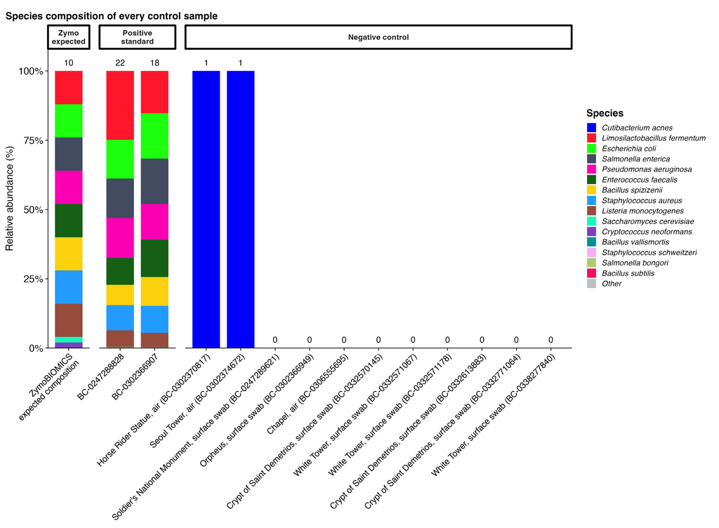

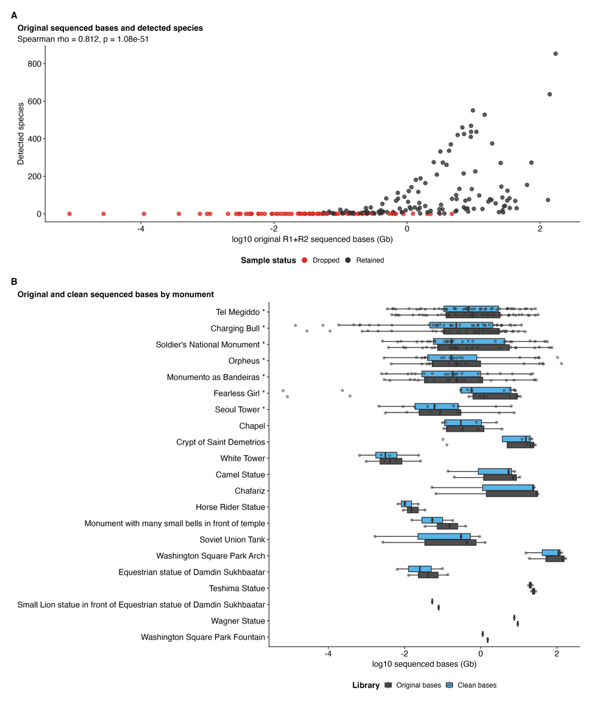

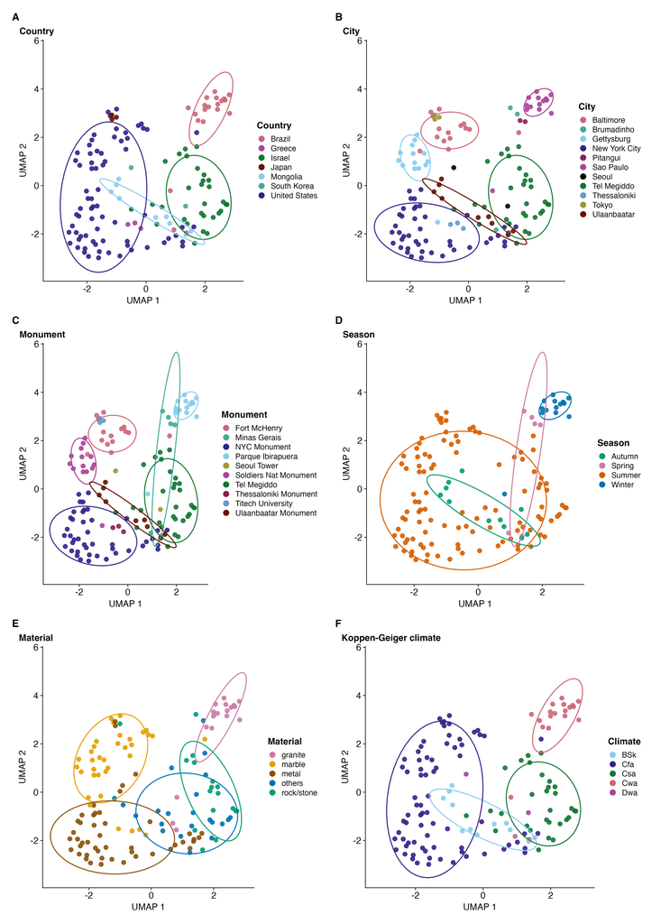

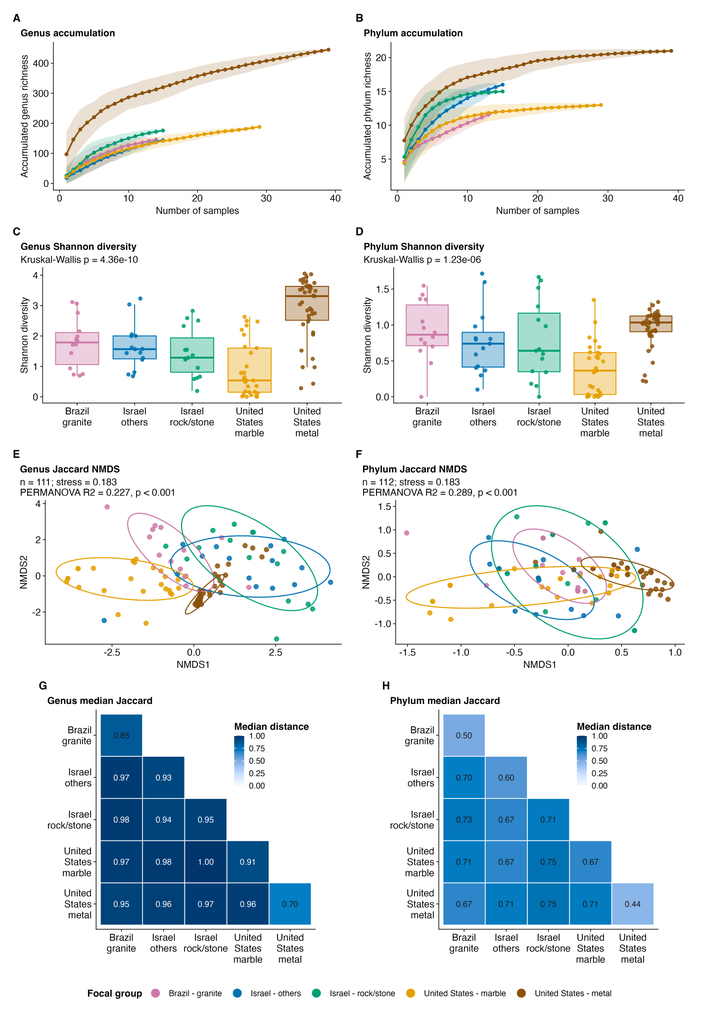

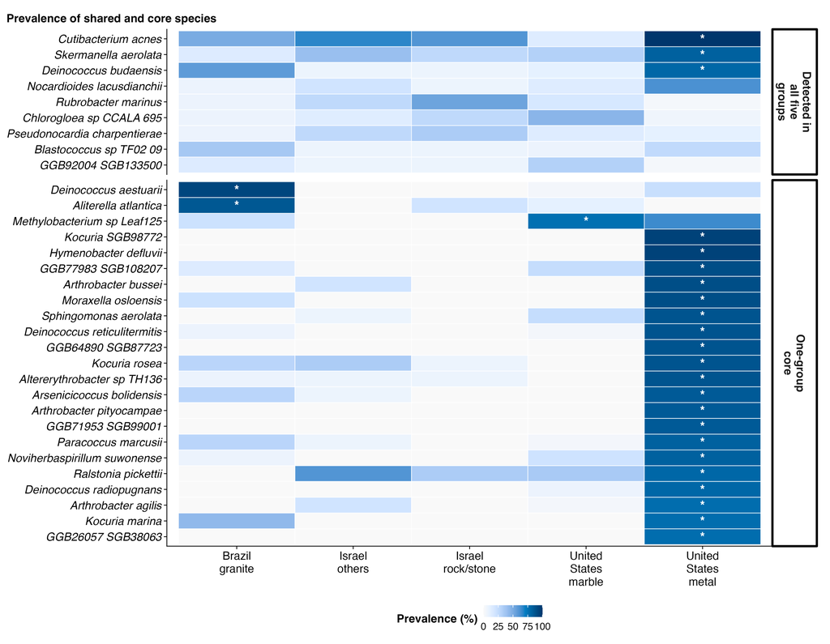

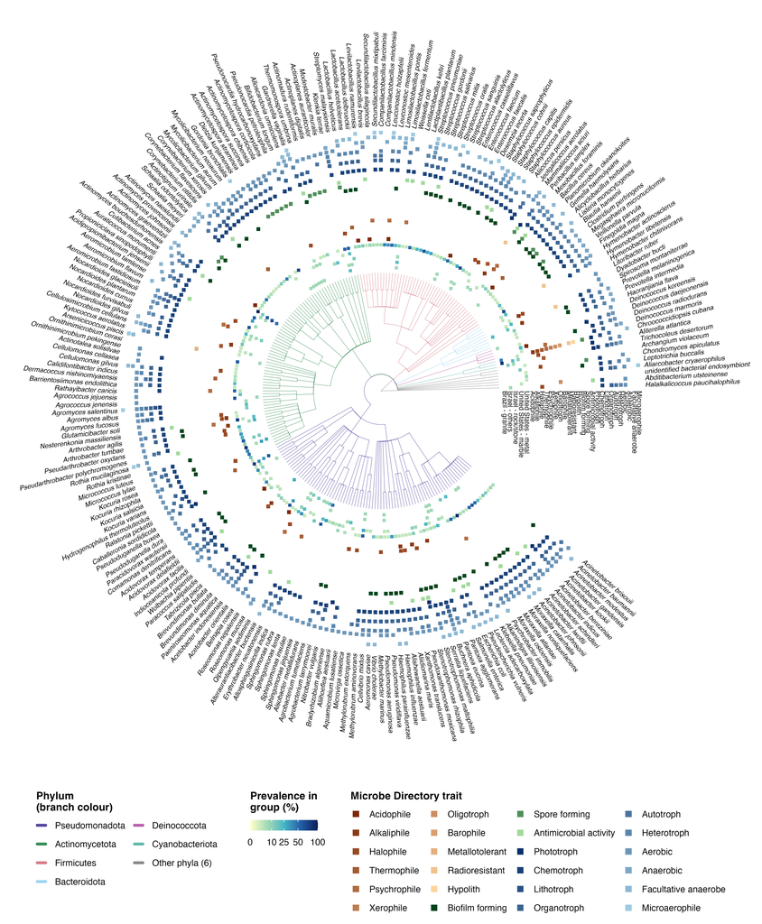

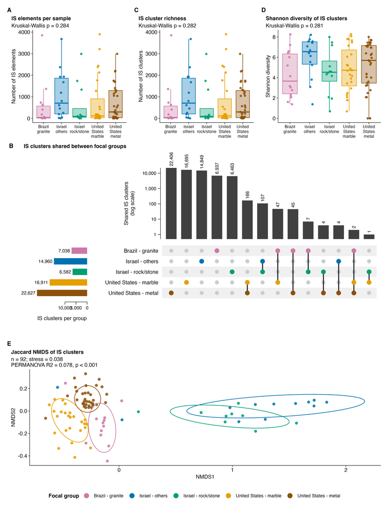

```r
set_figure_mode("print")
```